# Generalized Additive Models

Michael Liou

2022-05-08

# R Packages

- “mgcv” - Mixed GAM Computational Vehicle
  - `gamm` - for mixed models, uses `nlme` to fit
  - `gam` - can be used more general than exponential
  - `jagam` - interface to JAGS for bayesian estiamtion
- “gamm4” - like gamm, but with `lme4` in backend instead

Smooth functions in “mgcv”:

- `s()`- for univariate smooths, isotropic smooths, and random effects
- `te()` - tensor product smooths constructed from singly pernalized marginal smooths
- `ti()` - tensor product interactions with marginal smooth and lower order… for smooth anova models
- `t2()` alternative tensor product smooth construction,useful with gamm4 package. `

Smooth terms in GAMS, `bs = ""` - `tp` - low rank, thin plate splines, isotropic smoothers. Isotropic means that rotation of the covariate will not change the result of smoothing. thin plates don’t have “knots”, a truncated eigen-decomposition is used for rank reduction. low rank means fewer coefficients than data to smooth. - `ds` - duchon splines - `cr` - cubic regression spline - `cs` - shrinkage version of cubic splines - `cc` - cyclic cubic regression splines - `sos` - splines on the sphere - `ps` - psplines, b-spline basis and perform well generally - `cp` - cyclic version of p-spline

# Univariate Smoothing

4.2 of Wood.

Example on Engine data. Hypothesis is that larger the engine copacity, the faster the engine will wear out.

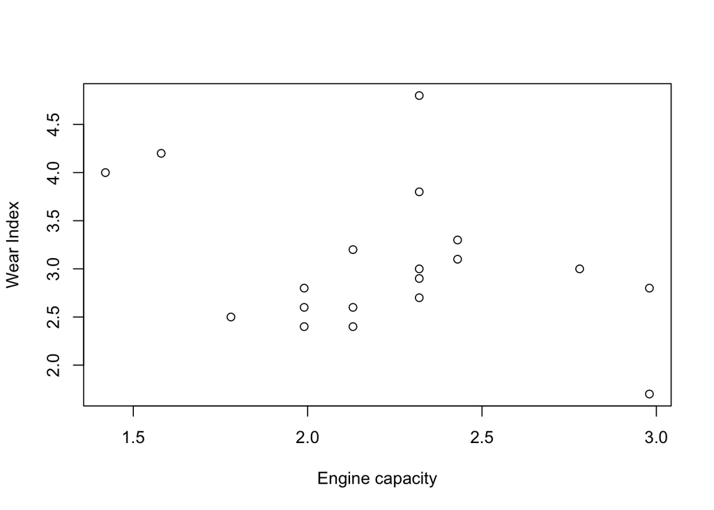

```r
# read engine data. Hypothesis is that
data(engine)
with(engine, plot(size, wear, xlab = "Engine capacity", ylab="Wear Index"))
```

- `xj` are the knots
- `x` is the data.

```r
# function for generating tent functions, the basis function
tf <- function(x, xj, j) {
  dj <- xj*0
  dj[j] <- 1
  approx(xj, dj, x)$y
}
tf.X <- function(x,xj) {
  # tent function basis matrix given data x, and knot sequence xj
  nk <- length(xj); n <- length(x)
  X <- matrix(NA, n, nk)
  for (j in 1:nk) {
    X[,j] <- tf(x,xj,j)
  }
  X
}
```

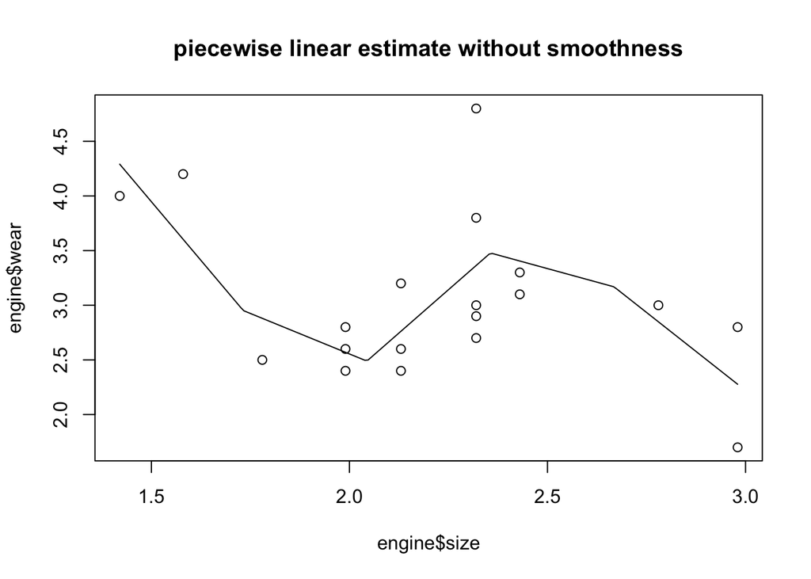

```r
sj <- seq(min(engine$size), max(engine$size), length=6)
X <- tf.X(engine$size,sj)
b <- lm(wear~X-1, data=engine)
s <- seq(min(engine$size), max(engine$size), length = 200) # prediction data
Xp <- tf.X(s,sj) # prediction matrix
plot(engine$size, engine$wear, main = "piecewise linear estimate without smoothness")
lines(s, Xp %*% coef(b))
```

cool, looks reasonable, but should introduce a penalty for the smoothness of the function

We wish to penalize the parameters with some function

$$\begin{aligned}
|| y-X\beta ||^2 + \lambda \beta'D'D\beta \\
= \bigg\| \begin{bmatrix} y \\ 0 \end{bmatrix} - \begin{bmatrix}X \\
\sqrt{\lambda}D\end{bmatrix}\bigg\|^2
\end{aligned}$$
For example, the penalty can be expressed in the matrix form

$$\begin{aligned}
\lambda \sum_{j=2}^{k-1}f(x^*_{j-1} - 2f(x^*_j) + f(x^*_{j+1}))^2
\end{aligned}$$

```r
diff(diag(5), differences=2)
```

```
##      [,1] [,2] [,3] [,4] [,5]
## [1,]    1   -2    1    0    0
## [2,]    0    1   -2    1    0
## [3,]    0    0    1   -2    1
```

```r
?diff
```

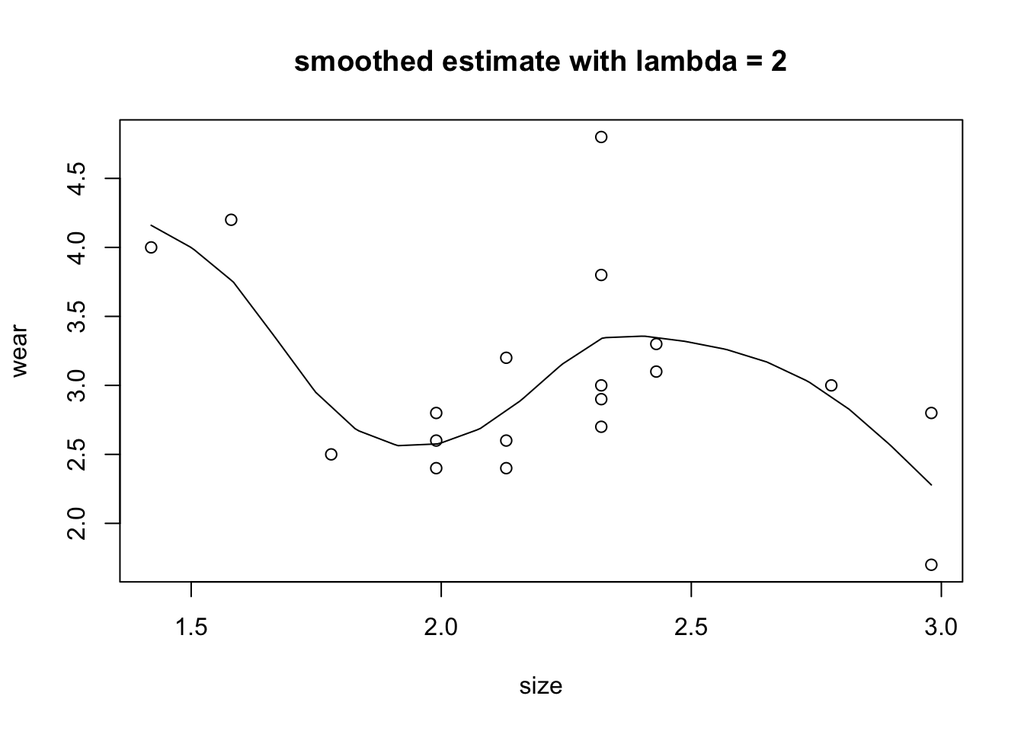

```r
#' penalized regression fit
#'
#' @param y response variable
#' @param x covariate
#' @param xj knot locations
#' @param sp smoothing parameter
#'
#' @return
#' @export
#'
#' @examples
prs.fit <- function(y,x, xj, sp) {
  X <- tf.X(x, xj) ## model matrix
  D <- diff(diag(length(xj)), differences=2) ## sqrt penalty, diff applied columnwise
  X <- rbind(X, sqrt(sp)*D) # augmented model matrix
  y <- c(y, rep(0, nrow(D))) # augmented data
  lm(y~X-1)
}

# fit the model
sj <- seq(min(engine$size), max(engine$size), length = 20) ## knots
b <- prs.fit(engine$wear, engine$size, sj, 2) # smoothing parameter = 2

# prediction data, with same knot locations
s <- seq(min(engine$size), max(engine$size), length = 200) # prediction data
Xp <- tf.X(s,sj)

with(engine, plot(size, wear, main = "smoothed estimate with lambda = 2"))
lines(s, Xp %*% coef(b))
```

## Examples

### Brain Imaging

```r
# specifying your own smoother
library(mgcv); library(MASS) ## load for mcycle data
```

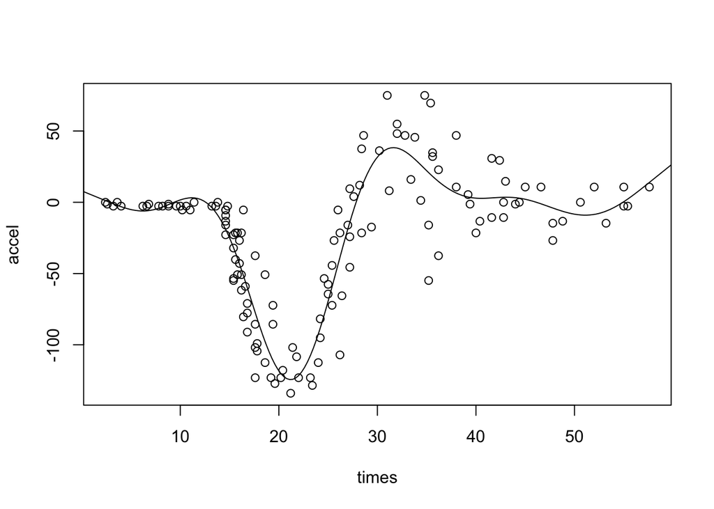

```r
sm <- smoothCon(s(times, k=10), data = mcycle, knots=NULL)[[1]]
beta <- coef(lm(mcycle$accel~sm$X-1))
# create predictions
times <- seq(0, 60, length = 200)
Xp <- PredictMat(sm, data.frame(times = times)) # get matrix mapping beta to spline predictions at times
with(mcycle, plot(times, accel))
lines(times, Xp %*% beta)
```

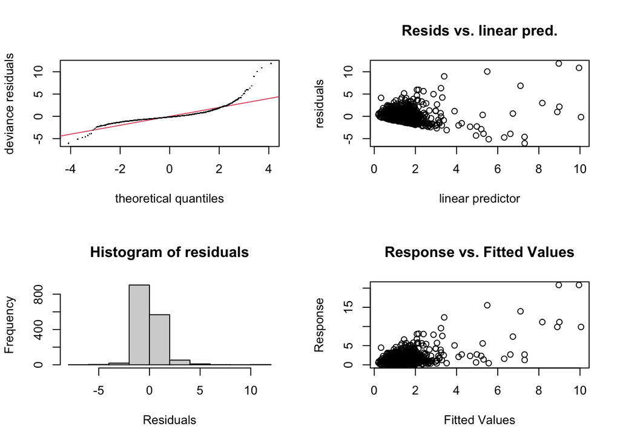

```
##
## Method: GCV   Optimizer: magic
## Smoothing parameter selection converged after 6 iterations.
## The RMS GCV score gradient at convergence was 6.236018e-05 .
## The Hessian was positive definite.
## Model rank =  100 / 100
##
## Basis dimension (k) checking results. Low p-value (k-index<1) may
## indicate that k is too low, especially if edf is close to k'.
##
##          k'  edf k-index p-value
## s(Y,X) 99.0 86.8    0.86  <2e-16 ***
## ---
## Signif. codes:  0 '***' 0.001 '**' 0.01 '*' 0.05 '.' 0.1 ' ' 1
```

```r
data(brain)
brain <- brain[brain$medFPQ > 5e-3,] # exclude 2 outliers
m0 <- gam(medFPQ ~ s(Y,X,k=100), data=brain)
gam.check(m0) # general diagnostics
```

- `k'` gives the maximum possible EDF for smooth df.

Residual plots look terrible, variance obviously increasing with mean. Assuming that there’s a power relationship with mean-variance,

$$\begin{aligned}
var(y_i) \propto \mu_i^\beta
\end{aligned}$$

```r
e <- residuals(m0); fv <- fitted(m0)
lm(log(e^2) ~ log(fv)) # log \sigma^2 ~ log mean
```

```
##
## Call:
## lm(formula = log(e^2) ~ log(fv))
##
## Coefficients:
## (Intercept)      log(fv)
##      -1.961        1.912
```

means that $\beta \approx 2$, implying that variance increases with square of the mean, so this is the gamma distribution. We could use the log link for the generalized linear family

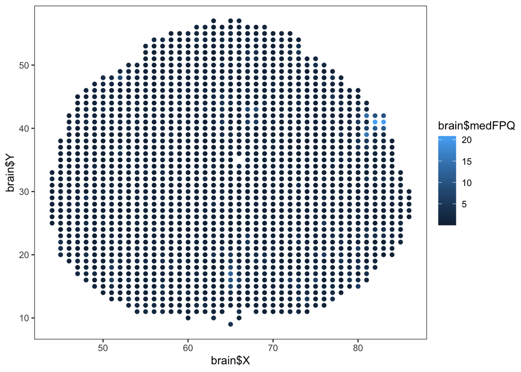

```r
qplot(brain$X, brain$Y, color = brain$medFPQ) + theme_test()
```